# Analysis of longitudinal data

## Task 1

### Reading the data

```r
RATS <- read.csv("RATSL.csv")

sapply(RATS, class)
```

```
##        ID     Group      time      gram
## "integer" "integer"  "factor" "integer"
```

> Categorical variables ID and Group are still in integer form, we need to convert them into the factors. Also note that time is a factor variable, we need to convert it into numeric one.

```r
RATS$ID <- as.factor(RATS$ID)
RATS$Group <- as.factor(RATS$Group)

RATS$time <- as.numeric(RATS$time)

sapply(RATS, class)
```

```
##        ID     Group      time      gram
##  "factor"  "factor" "numeric" "integer"
```

### Drawing the plot of RATS

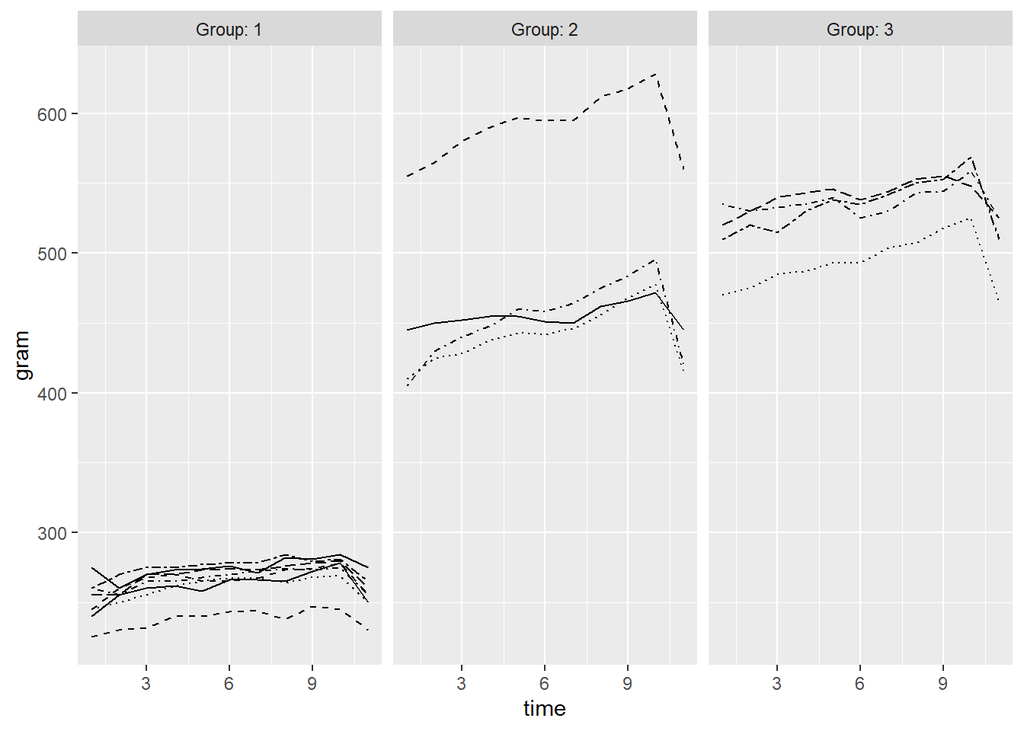

```r
library(ggplot2)

ggplot(RATS, aes(x = time, y = gram, linetype = ID)) +
  geom_line() +
  scale_linetype_manual(values = rep(1:10, times=4)) +
  facet_grid(. ~ Group, labeller = label_both) +
  theme(legend.position = "none") +
  scale_y_continuous(limits = c(min(RATS$gram), max(RATS$gram)))
```

### Standardizing the variable gram

```r
library(dplyr)
library(tidyr)

RATS <- RATS %>%
  group_by(time) %>%
  mutate(std_gram = (gram - mean(gram))/sd(gram) ) %>%
  ungroup()

glimpse(RATS)
```

```
## Observations: 176
## Variables: 5
## $ ID       <fct> 1, 2, 3, 4, 5, 6, 7, 8, 9, 10, 11, 12, 13, 14, 15, 16...
## $ Group    <fct> 1, 1, 1, 1, 1, 1, 1, 1, 2, 2, 2, 2, 3, 3, 3, 3, 1, 1,...
## $ time     <dbl> 1, 1, 1, 1, 1, 1, 1, 1, 1, 1, 1, 1, 1, 1, 1, 1, 11, 1...
## $ gram     <int> 240, 225, 245, 260, 255, 260, 275, 245, 410, 405, 445...
## $ std_gram <dbl> -1.0011429, -1.1203857, -0.9613953, -0.8421525, -0.88...
```

### Drawing the plot of RATS with standardised variable gram

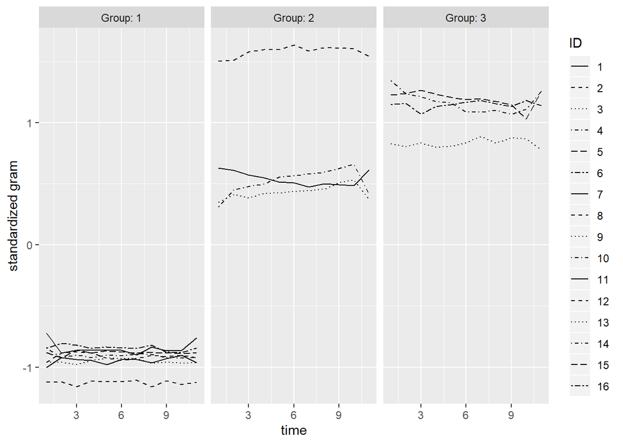

```r
ggplot(RATS, aes(x = time, y = std_gram, linetype = ID)) +
  geom_line() +
  scale_linetype_manual(values = rep(1:10, times=4)) +
  facet_grid(. ~ Group, labeller = label_both) +
  scale_y_continuous(name = "standardized gram")
```

> From the standardized curves we can better see the tracking phenomenon. Comparing this graph to the one with unstandardized values, the gram values of the second and third group stay the same over the whole period.

### Summarazing data with mean and standard error of gram by group and time and ploting the mean profiles

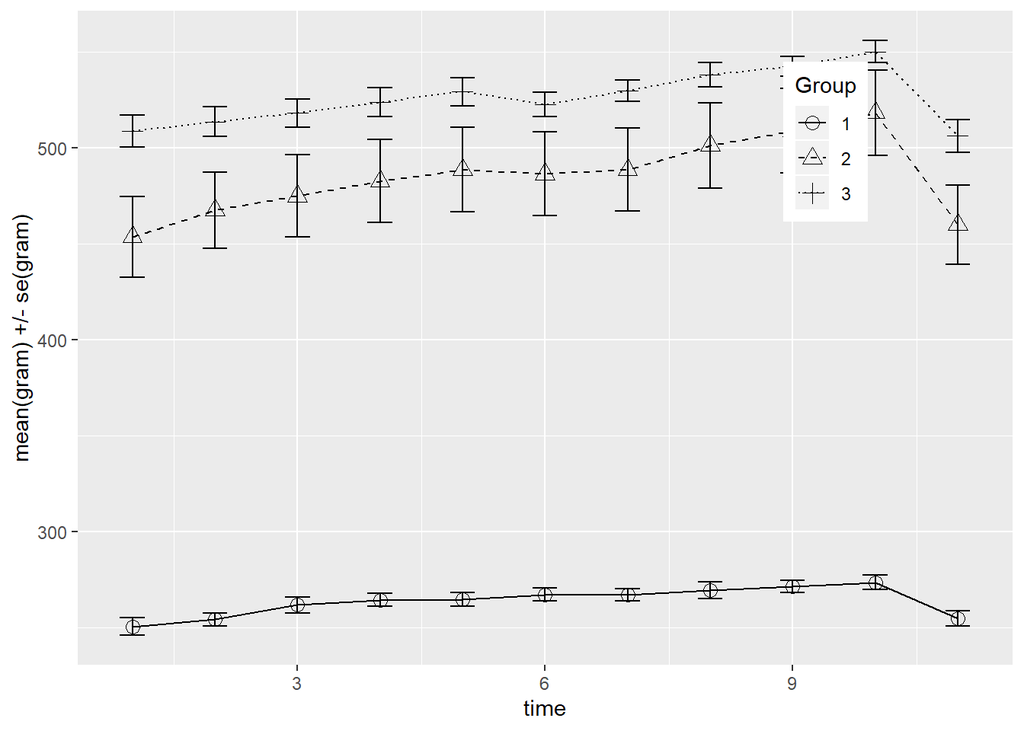

```r
n <- RATS$time %>% unique() %>% length()

RATSS <- RATS %>%
  group_by(Group, time) %>%
  summarise( mean = mean(gram), se = sd(gram)/sqrt(n) ) %>%
  ungroup()

ggplot(RATSS, aes(x = time, y = mean, linetype = Group, shape = Group)) +
  geom_line() +
  scale_linetype_manual(values = c(1,2,3)) +
  geom_point(size=3) +
  scale_shape_manual(values = c(1,2,3)) +
  geom_errorbar(aes(ymin = mean - se, ymax = mean + se, linetype="1"), width=0.3) +
  theme(legend.position = c(0.8,0.8)) +
  scale_y_continuous(name = "mean(gram) +/- se(gram)")
```

> The mean profiles of the second and third group follow the same pattern, although the mean profile of the third group is little bit higher on average. On the other hand, there is a huge difference between the first group and the other two groups with respect to the mean gram values, the mean profile of the first group is much lower comparing to other groups.

### Creating a summary data by group and ID with mean as the summary variable and drawing a boxplot of the mean versus Group

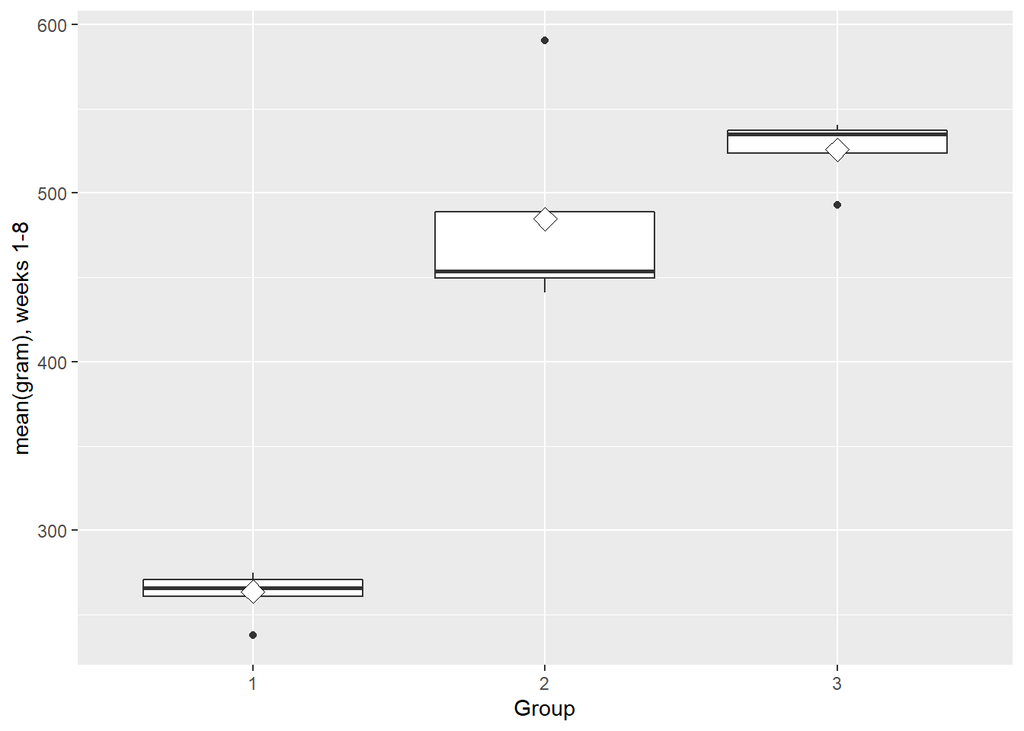

```r
RATSSS <- RATS %>%
  filter(time > 0) %>%
  group_by(Group, ID) %>%
  summarise( mean=mean(gram) ) %>%
  ungroup()

ggplot(RATSSS, aes(x = Group, y = mean)) +
  geom_boxplot() +
  stat_summary(fun.y = "mean", geom = "point", shape=23, size=4, fill = "white") +
  scale_y_continuous(name = "mean(gram), weeks 1-8")
```

> The black dots indicates, that there is an outlier in each group. Regarding the first and third group, the outlier is lower than other values. On the other hand, in the second group the outlier is much higher with a gram value equal almost to 600. We should consider remove those outliers, so they do not bias our results. Note also that the distribution of the second group is somewhat skewed.

## Task 2

### Reading the data

```r
BPRS <- read.csv("BPRSL.csv")

sapply(BPRS, class)
```

```
## treatment   subject     weeks      bprs
## "integer" "integer"  "factor" "integer"
```

> Categorical variables treatment and subject are still in integer form, we need to convert them into the factors. Also note that variable weeks is a factor variable, we need to convert it into numeric one.

```r
BPRS$treatment <- as.factor(BPRS$treatment)
BPRS$subject <- as.factor(BPRS$treatment)

BPRS$weeks <- as.numeric(BPRS$weeks)

sapply(BPRS, class)
```

```
## treatment   subject     weeks      bprs
##  "factor"  "factor" "numeric" "integer"
```